# Developing the R package for factor analysis

Step 1: Introduction to Factor Analysis

Factor analysis is a statistical method used to identify underlying factors or dimensions that explain patterns in observed variables. It is commonly employed to reduce the dimensionality of data and uncover latent structures. The technique is based on the assumption that observed variables are influenced by a smaller number of unobservable factors.

There are two types of factor analysis, including confirmatory and exploratory factor analysis. In this project, we will focus on developing custom package including function for running both exploring both exploratory and confirmatory factor analysis. For, confirmatory factor analysis we will include include function for calculating factor loadings, cronbach alpha value and model fit. Whereas, for exploratory factor analysis, we will include function for calculating factor loadings for individuals items and cronbach alpha.

Assumptions of Factor Analysis:

Data Characteristics: Factor analysis assumes the absence of outliers, a sufficient sample size (where the number of cases exceeds the number of variables), and interval-level data measurement.

Statistical Assumptions: Perfect multicollinearity among variables should be absent. Additionally, although the model assumes linearity, non-linear variables can be transformed to meet this requirement.

Step 2: Background of the Data

The dataset used in this project involves the validation of the Hearing Handicap Inventory for Adults - Screening Version (HHIA-S) questionnaire in the Nepali language. This questionnaire is commonly used to assess hearing impairment among adult populations over short periods. While translations of the questionnaire exist in various languages, including Indian, Swedish, and Spanish, there is a lack of a Nepali version. Therefore, the data collection aimed to validate the translated questionnaire among both hearing-impaired and normal-hearing populations (N = 50(HI), N = 70(NH))

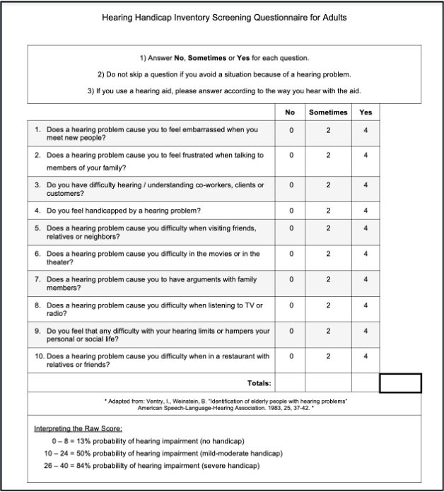

Prior to this paper (Aryal et al., 2022), there was no standardized Nepali translation of the HHIA-S questionnaire (originally in English). Factor analyses help to answer the questions, whether we could put the translation of the HHIA-S into use or not, and whether we could further use the data based on this questionnaire, the underlying structure and the way results are generated.

Both exploratory and confirmatory factor analyses were conducted on the dataset.

To put it simply, CFA may help to validate questionnaire with clear theoretical background, and structure and dimensions of the questions. For example, for the data set we use, it is adapted from a questionnaire being developed in many languages, and it is also concise, the main goal will be validating it so that Nepali language speaker could use this tool. If it is validated with CFA, future researches could be conducted based on this questionnaire as well in addition to informal use.

For an EFA, we assume that we are uncertain about the underlying structure and dimensions between the observed factors, namely questions. That is why in some current packages on FA, sometimes we do not have to directly input a model in the function. On the other hand, for a questionnaire with given structure, we could also suspect there is another competing theory, thus running comparison between two given models and decide which one is a better fit.

In real life, whether to perform CFA and EFA is a case-by-case decision based on the nature of and the work done for the questionnaire. A combination of CFA and EFA is also possible in analysis. Other procedures may be involved in addition to FA to validating questionnaires, e.g., in a linguistic/cultural adaptation of existing questionnaire, forming a panel (a bunch of people) to examine the questionnaire.

In our example, we try to use current packages to extract results of our interest in both EFA and CFA for demonstration purpose:

Factor loadings, which represent the correlation between variables and factors, played a crucial role in these analyses.Factor loadings were calculated for each items in the dataset. A factor loading of 0.5 or higher typically indicates that the factor sufficiently captures the variance of the variable.

Additionally, Cronbach’s alpha value were calculated for each datasets. Cronbach’s alpha measures the internal consistency of the scale or set of variables. A value closer to 1 indicates higher internal consistency

```r
#exploratory factor analysis
# Load required library, for exploratory factor analysis psych library is required (psych for both cronbach's alpha and EFA)
new_pkg <- c("tidyverse", "dplyr", "psych", "lavaan")
not_installed <- new_pkg[!new_pkg %in% rownames(installed.packages())]
if (length(not_installed) > 0) install.packages(not_installed)
library(psych)
library(dplyr)
library(tidyverse)
```

```
#> ✖ ggplot2::%+%()   masks psych::%+%()
```

```r
# Load data for normal hearing individuals and hearing impaired population
normal_hearing_data <- read.csv("NH_DATA.csv")
hearing_impaired_data <- read.csv("HI_DATA.csv")
usethis::use_data(normal_hearing_data, overwrite = TRUE) #creates .rda file for the data
```

```
#> ✔ Setting active project to '/private/var/folders/sr/p59cj11x08scxc4ng_5yfx3x72rn5k/T/Rtmp36qZ8K/Rbuild17d7e69ff7c42/FACTOR'
#> ✔ Saving 'normal_hearing_data' to 'data/normal_hearing_data.rda'
#> • Document your data (see 'https://r-pkgs.org/data.html')
```

```r
usethis::use_data(hearing_impaired_data, overwrite = TRUE)
```

```
#> ✔ Saving 'hearing_impaired_data' to 'data/hearing_impaired_data.rda'
#> • Document your data (see 'https://r-pkgs.org/data.html')
```

```r
#Clear empty observations. After this process the observations of two data frames matches the numbers of participants (N = 50(HI), N = 70(NH))
normal_hearing_data <- normal_hearing_data %>%
  select(-X) %>%
  drop_na(Age)
hearing_impaired_data <- hearing_impaired_data %>%
  select(-X) %>%
  drop_na(Age)

# Some "visualization" of the data
str(normal_hearing_data)
```

```
#> 'data.frame':    70 obs. of  15 variables:
#>  $ Timestamp : chr  "2021/04/09 6:54:17 pm GMT+5:30" "2021/04/09 6:59:46 pm GMT+5:30" "2021/04/09 7:00:11 pm GMT+5:30" "2021/04/09 7:41:12 pm GMT+5:30" ...
#>  $ Name      : chr  "sajana aryal" "Sujata Aryal" "Dipika Gnyawali" "Puspa khanal" ...
#>  $ Age       : int  24 22 24 24 23 26 21 23 23 22 ...
#>  $ Gender    : int  1 1 1 1 2 1 1 1 1 1 ...
#>  $ Profession: chr  "student" "Student" "Audiologist and Speech therapist" "Student" ...
#>  $ E1        : int  0 0 0 0 0 0 0 2 0 0 ...
#>  $ E2        : int  0 0 0 2 0 0 0 2 0 0 ...
#>  $ S3        : int  0 2 0 2 2 0 0 4 0 0 ...
#>  $ E4        : int  0 0 0 0 0 0 0 0 0 0 ...
#>  $ S5        : int  0 0 0 0 0 0 0 0 0 0 ...
#>  $ S6        : int  0 0 0 0 0 0 0 0 0 0 ...
#>  $ E7        : int  0 0 0 0 0 0 0 0 0 0 ...
#>  $ S8        : int  0 2 0 0 0 0 0 2 0 0 ...
#>  $ E9        : int  0 2 0 0 0 0 0 2 0 0 ...
#>  $ S10       : int  0 0 0 0 0 0 0 2 0 0 ...
```

```r
str(hearing_impaired_data)
```

```
#> 'data.frame':    50 obs. of  15 variables:
#>  $ Timestamp : chr  "5/26/2021 0:00:00" "5/26/2021 12:30:17" "5/26/2021 12:31:59" "5/26/2021 15:13:10" ...
#>  $ Name      : chr  "Krishna Bdr shrestha" "Hari Psd. Baral" "Hari Psd Baral" "Panchakumari Sharma" ...
#>  $ Age       : int  40 40 40 39 25 39 40 40 40 40 ...
#>  $ Gender    : int  1 1 1 2 2 2 1 1 2 2 ...
#>  $ Profession: chr  "Agriculture " "Farmer" "Farmer" "Housewife" ...
#>  $ E1        : int  2 2 4 0 2 2 4 4 4 4 ...
#>  $ E2        : int  4 4 4 2 2 2 4 4 4 4 ...
#>  $ S3        : int  2 2 2 2 2 2 4 4 4 4 ...
#>  $ E4        : int  2 2 2 0 0 0 2 4 2 2 ...
#>  $ S5        : int  2 4 4 2 2 0 4 4 4 4 ...
#>  $ S6        : int  4 4 4 0 2 2 2 2 2 2 ...
#>  $ E7        : int  2 2 2 0 0 2 2 2 2 2 ...
#>  $ S8        : int  2 2 4 0 0 2 4 2 4 4 ...
#>  $ E9        : int  4 2 2 0 0 2 4 2 4 4 ...
#>  $ S10       : int  2 2 2 0 2 2 4 2 4 4 ...
```

```r
head(normal_hearing_data)
```

```
#>                        Timestamp            Name Age Gender
#> 1 2021/04/09 6:54:17 pm GMT+5:30    sajana aryal  24      1
#> 2 2021/04/09 6:59:46 pm GMT+5:30    Sujata Aryal  22      1
#> 3 2021/04/09 7:00:11 pm GMT+5:30 Dipika Gnyawali  24      1
#> 4 2021/04/09 7:41:12 pm GMT+5:30    Puspa khanal  24      1
#> 5 2021/04/09 8:42:42 pm GMT+5:30    Subin sharma  23      2
#> 6 2021/04/09 9:19:40 pm GMT+5:30     DIBYA ARYAL  26      1
#>                         Profession E1 E2 S3 E4 S5 S6 E7 S8 E9 S10
#> 1                          student  0  0  0  0  0  0  0  0  0   0
#> 2                          Student  0  0  2  0  0  0  0  2  2   0
#> 3 Audiologist and Speech therapist  0  0  0  0  0  0  0  0  0   0
#> 4                          Student  0  2  2  0  0  0  0  0  0   0
#> 5                         Students  0  0  2  0  0  0  0  0  0   0
#> 6                              SLP  0  0  0  0  0  0  0  0  0   0
```

```r
head(hearing_impaired_data)
```

```
#>            Timestamp                 Name Age Gender   Profession E1 E2 S3 E4
#> 1  5/26/2021 0:00:00 Krishna Bdr shrestha  40      1 Agriculture   2  4  2  2
#> 2 5/26/2021 12:30:17      Hari Psd. Baral  40      1       Farmer  2  4  2  2
#> 3 5/26/2021 12:31:59       Hari Psd Baral  40      1       Farmer  4  4  2  2
#> 4 5/26/2021 15:13:10  Panchakumari Sharma  39      2    Housewife  0  2  2  0
#> 5  6/5/2021 11:33:07           Gita Thapa  25      2     Business  2  2  2  0
#> 6  6/5/2021 11:38:35      Sumitra Gautam   39      2     Business  2  2  2  0
#>   S5 S6 E7 S8 E9 S10
#> 1  2  4  2  2  4   2
#> 2  4  4  2  2  2   2
#> 3  4  4  2  4  2   2
#> 4  2  0  0  0  0   0
#> 5  2  2  0  0  0   2
#> 6  0  2  2  2  2   2
```

```r
# Define the questionnaire items for each group based on the column names
questionnaire_items <- c("E1", "E2", "S3", "E4", "S5", "S6", "E7", "S8", "E9", "S10")

# Define a function to calculate Cronbach's alpha and factor loadings for each group
calculate_alpha_and_loadings <- function(data, group_name) {
  # Select numeric variables
  numeric_data <- data[sapply(data, is.numeric)]

  # Perform factor analysis
  factor_analysis <- fa(numeric_data, nfactors = 1, rotate = "varimax")

  # Extract factor loadings
  factor_loadings <- factor_analysis$loadings

  # Print factor loadings
  print(paste("Factor Loadings for", group_name))
  print(factor_loadings)

  # Calculate Cronbach's alpha for all questionnaire items
  cronbach_alpha <- psych::alpha(numeric_data)$total$raw_alpha

  # Print Cronbach's alpha
  print(paste("Cronbach's Alpha for", group_name, ":", cronbach_alpha))
}

# Calculate Cronbach's alpha and factor loadings for normal hearing group
calculate_alpha_and_loadings(normal_hearing_data[questionnaire_items], "Normal Hearing")
```

```
#> [1] "Factor Loadings for Normal Hearing"
#>
#> Loadings:
#>     MR1
#> E1  0.611
#> E2  0.744
#> S3  0.675
#> E4  0.856
#> S5  0.920
#> S6  0.843
#> E7  0.666
#> S8  0.867
#> E9  0.818
#> S10 0.915
#>
#>                  MR1
#> SS loadings    6.371
#> Proportion Var 0.637
#> [1] "Cronbach's Alpha for Normal Hearing : 0.940015933830565"
```

```r
# Calculate Cronbach's alpha and factor loadings for hearing impaired group
calculate_alpha_and_loadings(hearing_impaired_data[questionnaire_items], "Hearing Impaired")
```

```
#> [1] "Factor Loadings for Hearing Impaired"
#>
#> Loadings:
#>     MR1
#> E1  0.762
#> E2  0.871
#> S3  0.734
#> E4  0.841
#> S5  0.844
#> S6  0.714
#> E7  0.592
#> S8  0.675
#> E9  0.782
#> S10 0.803
#>
#>                  MR1
#> SS loadings    5.869
#> Proportion Var 0.587
#> [1] "Cronbach's Alpha for Hearing Impaired : 0.933131771227009"
```

```r
#Perform confirmatory factor analysis
#for CFA and Cronbach's alpha, both lavaan and psych are required (Cronbach's alpha  required psych)
# Load required libraries
library(lavaan)
library(psych)

# Load data for normal hearing individuals and hearing impaired population
normal_hearing_data <- read.csv("NH_DATA.csv")
hearing_impaired_data <- read.csv("HI_DATA.csv")

#Clear empty observations. After this process the observations of two data frames matches the numbers of participants (N = 50(HI), N = 70(NH))
normal_hearing_data <- normal_hearing_data %>%
  select(-X) %>%
  drop_na()
hearing_impaired_data <- hearing_impaired_data %>%
  select(-X) %>%
  drop_na()

# Define the questionnaire items for each group based on the column names
questionnaire_items <- c("E1", "E2", "S3", "E4", "S5", "S6", "E7", "S8", "E9", "S10")

# Define a function to perform confirmatory factor analysis (CFA) and calculate Cronbach's alpha and factor loadings for each group
perform_CFA <- function(data, group_name) {
  # Define the CFA model
  model <- '
    # Define latent variable
    factor =~ E1 + E2 + S3 + E4 + S5 + S6 + E7 + S8 + E9 + S10
  '

  # Perform CFA
  fit <- lavaan::cfa(model, data = data, std.lv = TRUE)
  print(fit)
  # Print standardized factor loadings
  print(paste("Standardized Factor Loadings for", group_name))
  print(inspect(fit, "std")$lambda)

  # Extract standardized factor loadings
  factor_loadings <- inspect(fit, "std")$lambda

  # Calculate Cronbach's alpha for all questionnaire items
  cronbach_alpha <- psych::alpha(data)$total$raw_alpha

  # Print Cronbach's alpha
  print(paste("Cronbach's Alpha for", group_name, ":", cronbach_alpha))
}

# Perform confirmatory factor analysis and Cronbach's alpha for normal hearing group
perform_CFA(normal_hearing_data[questionnaire_items], "Normal Hearing")
```

```
#> lavaan 0.6.17 ended normally after 27 iterations
#>
#>   Estimator                                         ML
#>   Optimization method                           NLMINB
#>   Number of model parameters                        20
#>
#>   Number of observations                            70
#>
#> Model Test User Model:
#>
#>   Test statistic                                92.415
#>   Degrees of freedom                                35
#>   P-value (Chi-square)                           0.000
#> [1] "Standardized Factor Loadings for Normal Hearing"
#>     factor
#> E1   0.602
#> E2   0.754
#> S3   0.649
#> E4   0.875
#> S5   0.938
#> S6   0.858
#> E7   0.647
#> S8   0.857
#> E9   0.787
#> S10  0.911
#> [1] "Cronbach's Alpha for Normal Hearing : 0.940015933830565"
```

```r
# Perform confirmatory factor analysis and Cronbach's alpha for hearing impaired group
perform_CFA(hearing_impaired_data[questionnaire_items], "Hearing Impaired")
```

```
#> lavaan 0.6.17 ended normally after 18 iterations
#>
#>   Estimator                                         ML
#>   Optimization method                           NLMINB
#>   Number of model parameters                        20
#>
#>   Number of observations                            50
#>
#> Model Test User Model:
#>
#>   Test statistic                                56.112
#>   Degrees of freedom                                35
#>   P-value (Chi-square)                           0.013
#> [1] "Standardized Factor Loadings for Hearing Impaired"
#>     factor
#> E1   0.745
#> E2   0.877
#> S3   0.730
#> E4   0.828
#> S5   0.856
#> S6   0.746
#> E7   0.597
#> S8   0.667
#> E9   0.766
#> S10  0.803
#> [1] "Cronbach's Alpha for Hearing Impaired : 0.933131771227009"
```

Step 3: Develeloping the Custom R Package As we can see above, the current FA functions (handy ones for dummies), may exist in different packages. We create a custom R package that includes functions for both exploratory and confirmatory factor analysis. These functions will streamline the process of conducting factor analysis for users.

```r
library(FACTOR)
library(dplyr)
library(tidyverse)
```

Step 4: Preparing for analysis We created a function `pick_check()` which intake two arguments: data and the type of test for checking whether the data is appropriate for FA. For example, we can input `"KMO"` to see the result of KMO test.

```r
pick_check("KMO", hearing_impaired_data[questionnaire_items])
```

```
#> # KMO Measure of Sampling Adequacy
#>
#> The Kaiser, Meyer, Olkin (KMO) overall measure of sampling adequacy suggests that data seems appropriate for factor analysis (KMO = 0.89). The individual KMO scores are: E1 (0.89), E2 (0.86), S3 (0.88), E4 (0.93), S5 (0.91), S6 (0.85), E7 (0.89), S8 (0.85), E9 (0.94), S10 (0.90).
```

```r
pick_check("Bartlett", normal_hearing_data[questionnaire_items])
```

```
#> # Test of Sphericity
#>
#> Bartlett's test of sphericity suggests that there is sufficient significant correlation in the data for factor analysis (Chisq(45) = 607.78, p < .001).
```

The results states that both datasets seem appropriate for FA.

Step 5: Performing Confirmatory Factor Analysis using the custom created package “FACTOR” (includes factor loadings and Cronbach’s alpha, and model fit)

Load dataset and clean empty observations

```r
normal_hearing_data <- read.csv("NH_DATA.csv")
hearing_impaired_data <- read.csv("HI_DATA.csv")
normal_hearing_data <- normal_hearing_data %>%
  select(-X) %>%
  drop_na()
hearing_impaired_data <- hearing_impaired_data %>%
  select(-X) %>%
  drop_na()
```

```r
questionnaire_items <- c("E1","E2","S3","E4","S5","S6","E7","S8", "E9", "S10")
```

Check CFA factor loadings

```r
model <-
   " # Define latent variable
    factor =~ E1 + E2 + S3 + E4 + S5 + S6 + E7 + S8 + E9 + S10
    "
get_loadings_model(model, normal_hearing_data[questionnaire_items], "Normal Hearing")
```

```
#> [1] "Standardized Factor Loadings for Normal Hearing"
#>     factor
#> E1   0.602
#> E2   0.754
#> S3   0.649
#> E4   0.875
#> S5   0.938
#> S6   0.858
#> E7   0.647
#> S8   0.857
#> E9   0.787
#> S10  0.911
```

```r
get_loadings_model(model, hearing_impaired_data[questionnaire_items], "Hearing Impaired")
```

```
#> [1] "Standardized Factor Loadings for Hearing Impaired"
#>     factor
#> E1   0.745
#> E2   0.877
#> S3   0.730
#> E4   0.828
#> S5   0.856
#> S6   0.746
#> E7   0.597
#> S8   0.667
#> E9   0.766
#> S10  0.803
```

Check Cronbach’s Alpha value

```r
model <-
   " # Define latent variable
    factor =~ E1 + E2 + S3 + E4 + S5 + S6 + E7 + S8 + E9 + S10
    "
get_alpha_model(model, normal_hearing_data[questionnaire_items], "Normal Hearing")
```

```
#> [1] "Cronbach's Alpha for Normal Hearing : 0.940015933830565"
```

```r
get_alpha_model(model, hearing_impaired_data[questionnaire_items], "Hearing Impaired")
```

```
#> [1] "Cronbach's Alpha for Hearing Impaired : 0.933131771227009"
```

Check Model’s fit

```r
model <-
   " # Define latent variable
    factor =~ E1 + E2 + S3 + E4 + S5 + S6 + E7 + S8 + E9 + S10
    "
handy_fit(model, normal_hearing_data[questionnaire_items])
```

```
#>  chisq     df pvalue    cfi    tli  rmsea   srmr
#> 92.415 35.000  0.000  0.906  0.879  0.153  0.056
```

```r
handy_fit(model, hearing_impaired_data[questionnaire_items])
```

```
#>  chisq     df pvalue    cfi    tli  rmsea   srmr
#> 56.112 35.000  0.013  0.936  0.918  0.110  0.062
```

Here are some fit statistics introduction and their reference levels (Maindal et al. 2012):

- `Chi-squared goodness-of-fit statistic` assesses the discrepancy between the sample and fitted covariance matrix (the null hypothesis is that the model fits the data. An insignificant test indicates good fit (`P-value` above 0.1). P-values of this model for two data sets do not indicate good fits.
- `Comparative fit index (CFI)` assesses fit relative to a null model and ranges from 0 to 1 with values of 0.90–0.95 indicating acceptable and over 0.95 good fit. For this model, CFI indicates acceptable fits.
- `Tucker Lewis index (TLI)` adjusts for the number of model parameters and is interpreted as CFI.
- `Root mean square error of approximation (RMSEA)` expresses the lack of fit per degree of freedom of the model. Values are interpreted as follows: =<0.05 indicates very good, 0.05–0.08 good and >=0.10 poor fit. For this model, RMSEAs indicate poor fits.
- `Standardized root mean square residual (SRMR)` is the average of the differences between the observed and predicted correlations and has a range from 0 to 1. Values of <0.08 indicate good fit. For this model, SRMRs indicate good fits.

Step 7: Performing exploratory Factor Analysis using the custom created package “FACTOR” (includes factor loadings and Cronbach’s alpha, and model comparison)

```r
get_loadings(normal_hearing_data[questionnaire_items], 1, "Normal Hearing")
```

```
#> [1] "Factor Loadings for Normal Hearing"
#>
#> Loadings:
#>     MR1
#> E1  0.611
#> E2  0.744
#> S3  0.675
#> E4  0.856
#> S5  0.920
#> S6  0.843
#> E7  0.666
#> S8  0.867
#> E9  0.818
#> S10 0.915
#>
#>                  MR1
#> SS loadings    6.371
#> Proportion Var 0.637
```

```r
get_loadings(hearing_impaired_data[questionnaire_items], 1, "Hearing Impaired")
```

```
#> [1] "Factor Loadings for Hearing Impaired"
#>
#> Loadings:
#>     MR1
#> E1  0.762
#> E2  0.871
#> S3  0.734
#> E4  0.841
#> S5  0.844
#> S6  0.714
#> E7  0.592
#> S8  0.675
#> E9  0.782
#> S10 0.803
#>
#>                  MR1
#> SS loadings    5.869
#> Proportion Var 0.587
```

```r
get_alpha(normal_hearing_data[questionnaire_items], 1, "Normal Hearing")
```

```
#> [1] "Cronbach's Alpha for Normal Hearing : 0.940015933830565"
```

```r
get_alpha(hearing_impaired_data[questionnaire_items], 1, "Hearing Imapired")
```

```
#> [1] "Cronbach's Alpha for Hearing Imapired : 0.933131771227009"
```

We might want to compare between model fits. By changing the second argument in in the functions in the chunk above could help with exploration. On the other hand, we could write two models and compare between the fits using `compare_fit()` function, which intake two models as the first two arguments and the data as the third argument.

For these datasets, we don’t necessarily need to test other models due to the nature of the datasets. Here we just randomly write a second function as an example to demonstrate the function.

```r
model_test <- "
    # Define latent variable
factor1 =~ E1 + E2 + S3 + E4 + S5 + S6 + E7 + S8
factor2 =~ E9 + S10
  "
```

```r
compare_fit(model, model_test, hearing_impaired_data[questionnaire_items])
```

```
#>
#> Chi-Squared Difference Test
#>
#>       Df    AIC    BIC  Chisq Chisq diff RMSEA Df diff Pr(>Chisq)
#> fit_2 34 1544.8 1585.0 55.685
#> fit_1 35 1543.2 1581.5 56.112    0.42691     0       1     0.5135
```

Step 6: Comparision of workflow using original Lavaan and psych package, and custom FACTOR package

The results of factor loadings, cronbach’s alpha , and models fit for included datset is same using original package and custom made package. Hence, this proves we successfully created the custom package called “FACTOR”. We bundled several functions from r packages focusing on FA and also included some created custom ones which helps us extract information/statistics in our FA.

References:

- Aryal, S., Bhattarai, B., & Prabhu, P. (2022). Development and Standardization of Hearing Handicap Inventory for Adult (Screening Version) in Nepali Language. Indian Journal of Otolaryngology and Head & Neck Surgery, 74(Suppl 3), 4409-4414.
- Kline, P. (2014). An easy guide to factor analysis. Routledge.
- Flora, D. B., LaBrish, C., & Chalmers, R. P. (2012). Old and new ideas for data screening and assumption testing for exploratory and confirmatory factor analysis. Frontiers in Psychology, 3, 55.
- Maindal, H. T., Sokolowski, I., & Vedsted, P. (2012). Adaptation, data quality and confirmatory factor analysis of the Danish version of the PACIC questionnaire. The European Journal of Public Health, 22(1), 31-36.
- Tavakol, M., & Dennick, R. (2011). Making sense of Cronbach’s alpha. Int J Med Educ, 2, 53-55. https://doi.org/10.5116/ijme.4dfb.8dfd
- Thompson, B. (2004). Exploratory and confirmatory factor analysis: Understanding concepts and applications. Washington, DC, 10694(000), 3.